# Assignment 6: Visualization - Aesthetic Mapping

*How to do it?*:

- Open the Rmarkdown file of this assignment (link) in Rstudio.
- Right under each **question**, insert a code chunk (you can use the hotkey `Ctrl + Alt + I` to add a code chunk) and code the solution for the question.
- `Knit` the rmarkdown file (hotkey: `Ctrl + Alt + K`) to export an html.
- Publish the html file to your Githiub Page.

*Submission*: Submit the link on Github of the assignment to Blackboard.

**Questions**

Use the data of your own. Produce the following types of plots and comment on each plot. Plots should be meaningful. If you use the data we used in class, make sure the plots are not the same as the ones in the slides.

```r
library(tidyverse)
df <- read_csv('all-states-history.csv')
```

1. For one continuous variable:
- Density: We can see the density for “MI” and “MN” in terms of the variable “hospitaledIncrease”. We can see the density plot looks like an L shape.

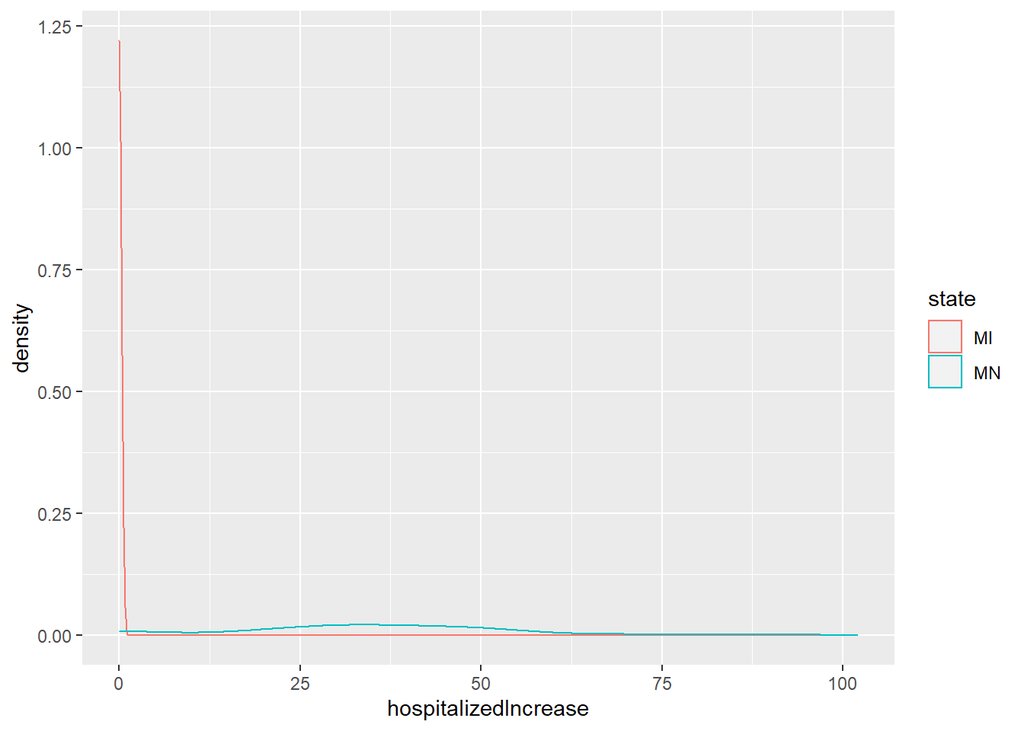

```r
df %>% filter(state=='MI' | state=='MN') %>% ggplot() +
  geom_density(mapping = aes(x = hospitalizedIncrease, color = state))
```

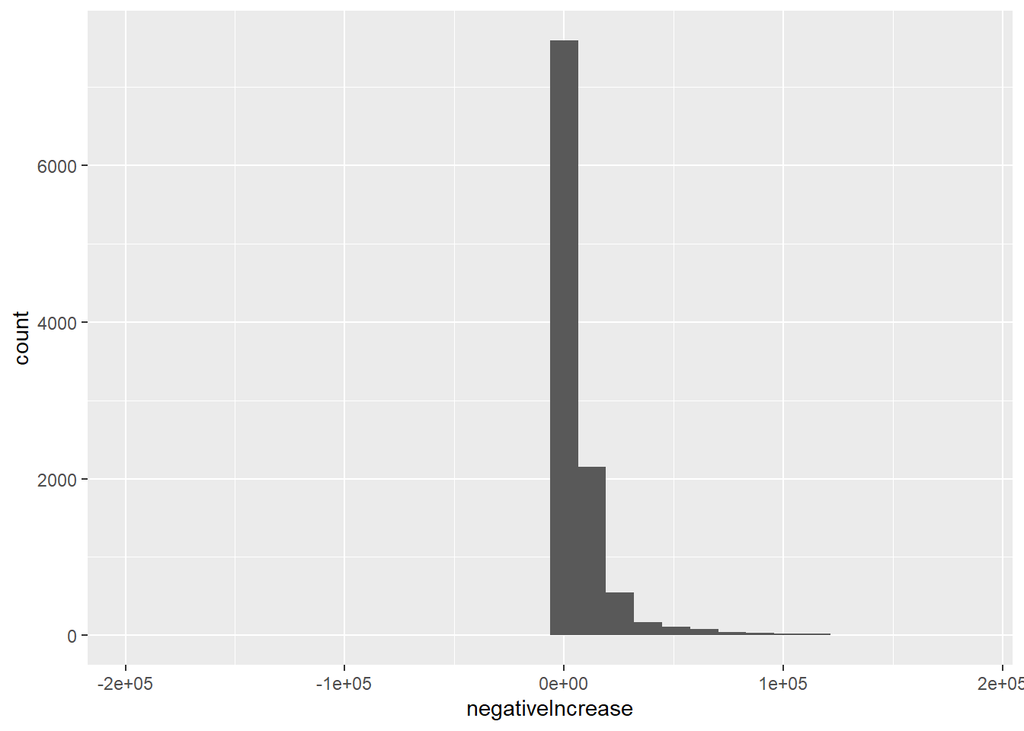

```r
df %>% ggplot() +
  geom_histogram(mapping = aes(x = negativeIncrease))
```

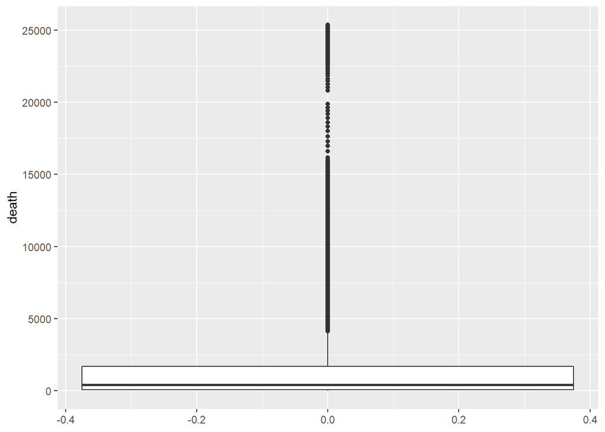

```r
df %>% ggplot() +
  geom_boxplot(mapping = aes(y = death))
```

2. For one categorical variable
- Barplot: This shows us the total amount for each letter grade. We can see the top “DataQualityGrade” values are A, A+, and B.

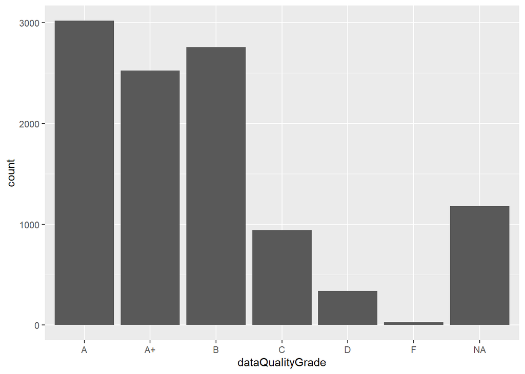

```r
df %>% ggplot() +
  geom_bar(mapping = aes(x = dataQualityGrade))
```

3. For one two continuous variables
- Scatter Plot: We can see the relationship between death and death increase here. This scatter plot looks skewed right with a couple of outliers.

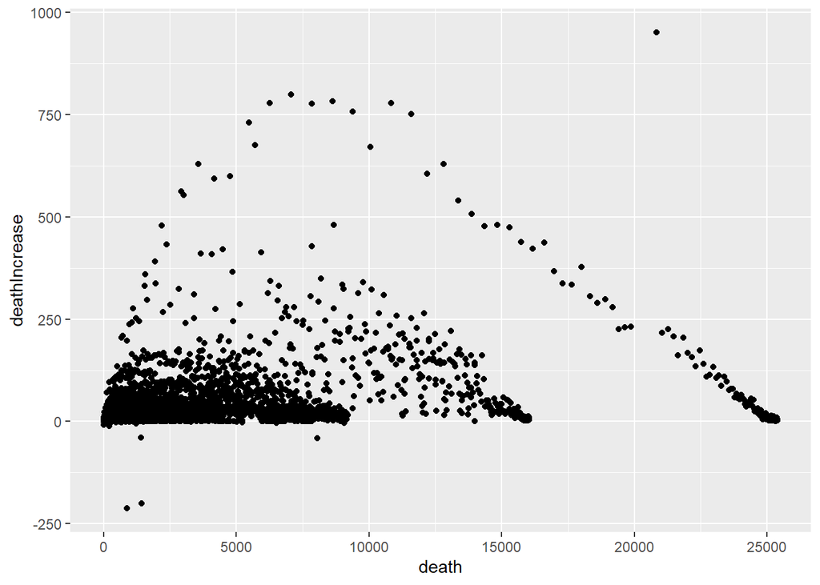

```r
df %>% ggplot() +
  geom_point(mapping = aes(x = death, y = deathIncrease))
```

- Line Plot: We can see the relationship between “hospitalizedCurrently” and “positiveIncrease”. It makes sense for them to be highly correlated as they are directly related.

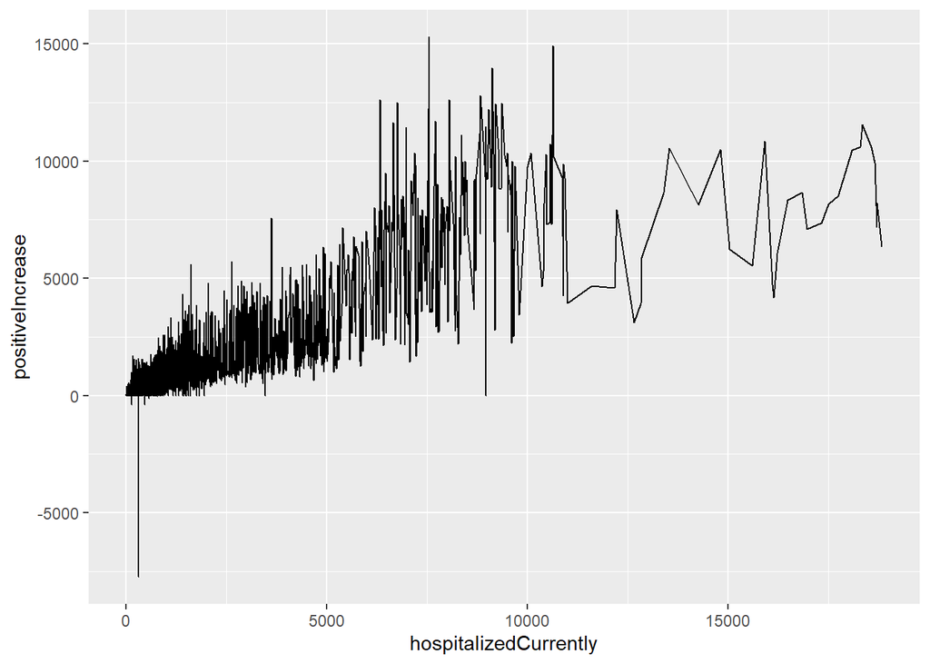

```r
df %>% ggplot() +
  geom_line(mapping = aes(x = hospitalizedCurrently, y =positiveIncrease))
```

- Smooth Plot: These two variables correlate well because the more people that are hospitalized, the more the deaths will increase.

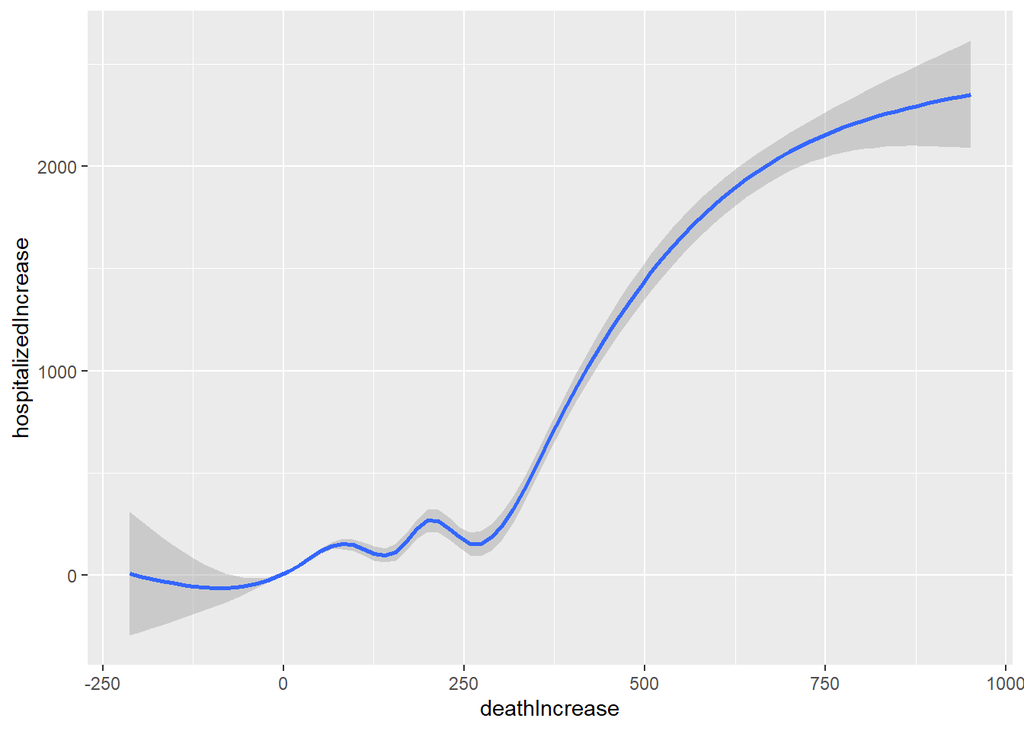

```r
df %>% ggplot() +
  geom_smooth(mapping = aes(x = deathIncrease, y = hospitalizedIncrease))
```

4. For one continuous + one categorical variables
- Density: This density plot shows the data quality control among the people that are hospitalized. This is a very up-and-down plot.

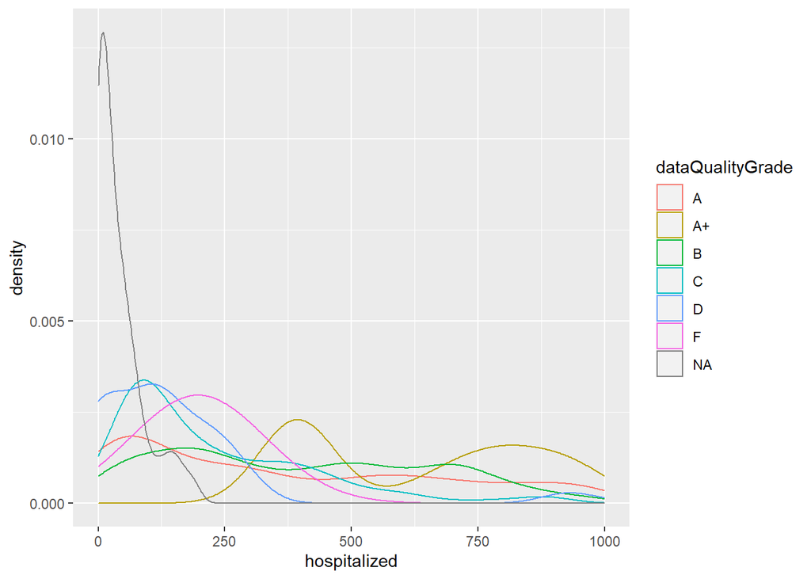

```r
df %>% filter(hospitalized<1000) %>% ggplot() +
  geom_density(mapping = aes(x = hospitalized, color = dataQualityGrade))
```

- BoxPlot: The box plot further shows the relationship between these two variables. There are a few outliers present.

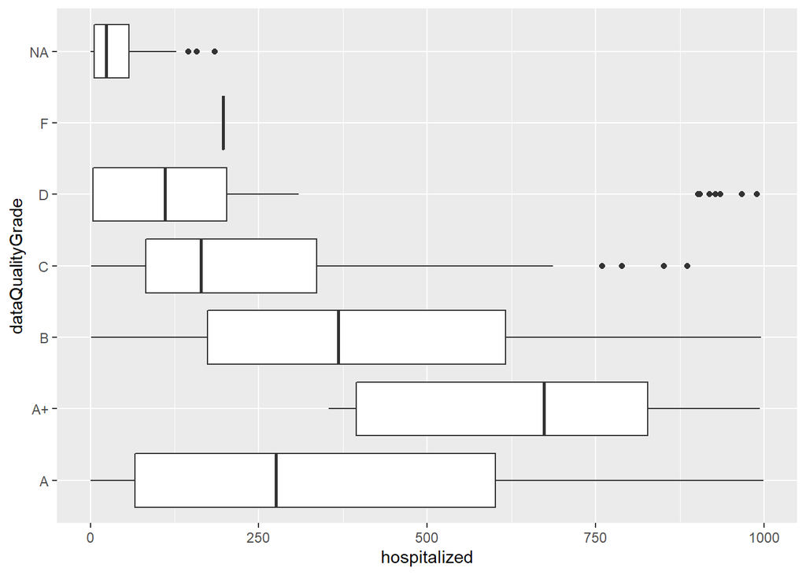

```r
df %>% filter(hospitalized<1000) %>% ggplot() +
  geom_boxplot(mapping = aes(x = hospitalized, y = dataQualityGrade))
```

5. For two categorical variables: barplot: This simply shows us the dataqualitygrade among all of the states. We can see “A” is the highest and “F” clearly has the lowest amount.

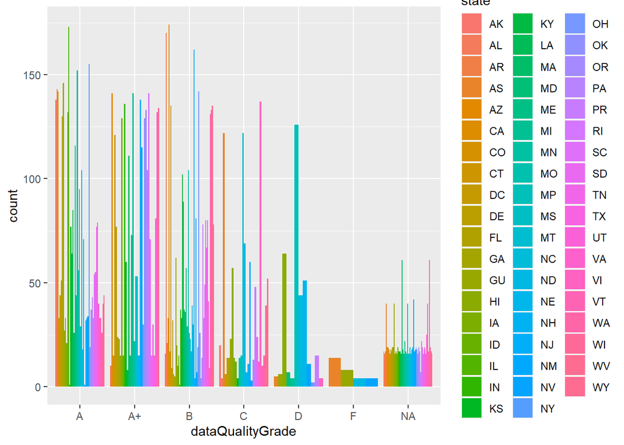

```r
df %>% ggplot() +
  geom_bar(mapping = aes(x = dataQualityGrade, fill = state), position='dodge')
```